# Data_mining_final_prj_Analysis

```r
# Create scatter plots with fitted regression lines for each predictor

"Percentage Population 0-4 vs COVID Case Count per Population"
```

```
## [1] "Percentage Population 0-4 vs COVID Case Count per Population"
```

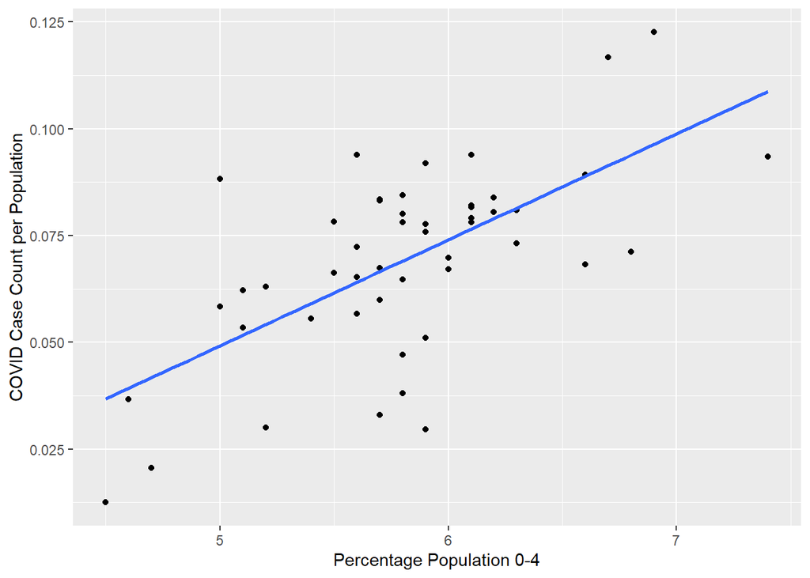

```r
 ggplot(master_copy_2020, aes(x = Percentage_population_0_4, y = covid_case_count_per_pop)) +
  geom_point() +
  geom_smooth(method = "lm", se = FALSE) +
  labs(x = "Percentage Population 0-4", y = "COVID Case Count per Population")
```

```r
 "Percentage Population 5-19 vs COVID Case Count per Population"
```

```
## [1] "Percentage Population 5-19 vs COVID Case Count per Population"
```

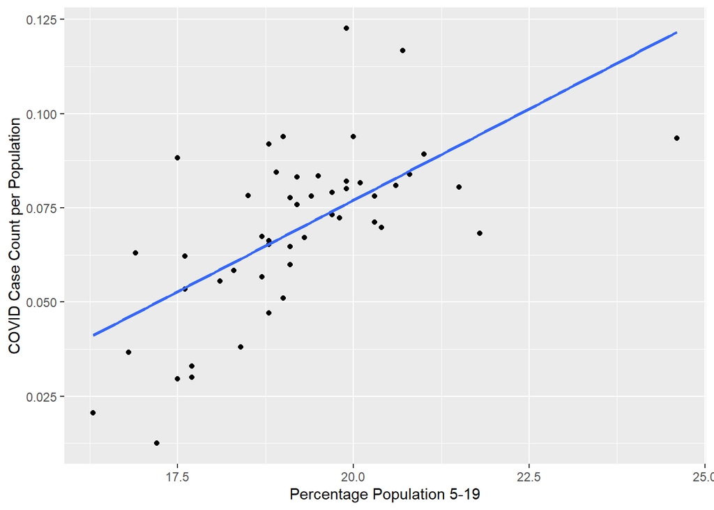

```r
 ggplot(master_copy_2020, aes(x = Percentage_population_5_19, y = covid_case_count_per_pop)) +
  geom_point() +
  geom_smooth(method = "lm", se = FALSE) +
  labs(x = "Percentage Population 5-19", y = "COVID Case Count per Population")
```

```r
 "Percentage Population 20-34 vs COVID Case Count per Population"
```

```
## [1] "Percentage Population 20-34 vs COVID Case Count per Population"
```

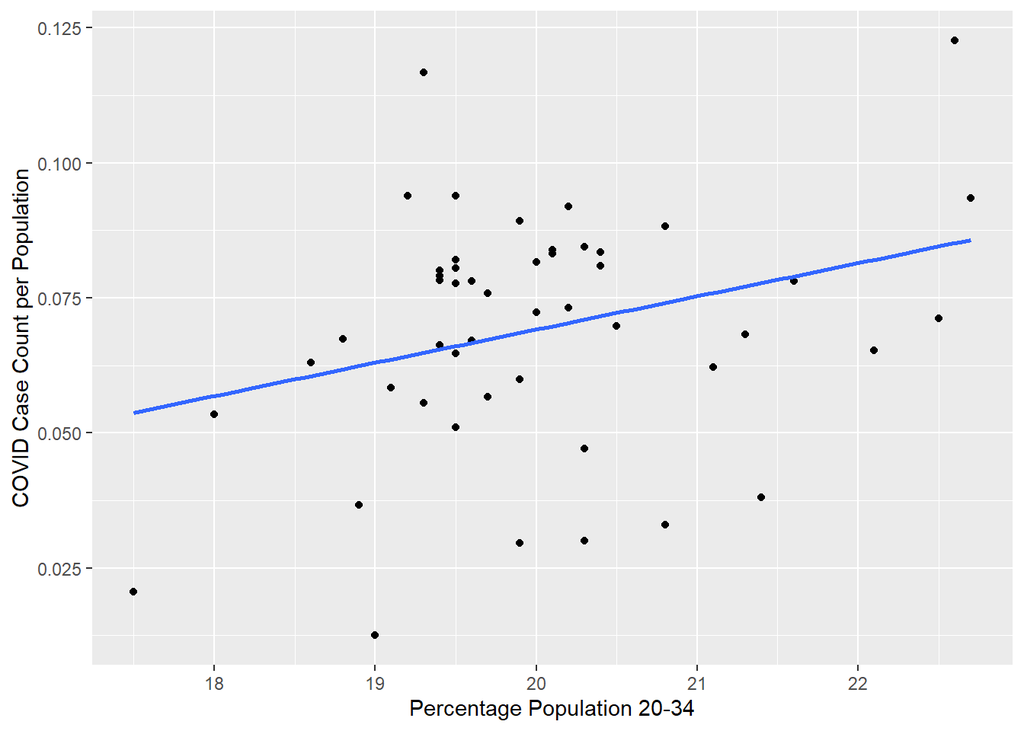

```r
ggplot(master_copy_2020, aes(x = Percentage_population_20_34, y = covid_case_count_per_pop)) +
  geom_point() +
  geom_smooth(method = "lm", se = FALSE) +
  labs(x = "Percentage Population 20-34", y = "COVID Case Count per Population")
```

```r
"Percentage Population 35-54 vs COVID Case Count per Population"
```

```
## [1] "Percentage Population 35-54 vs COVID Case Count per Population"
```

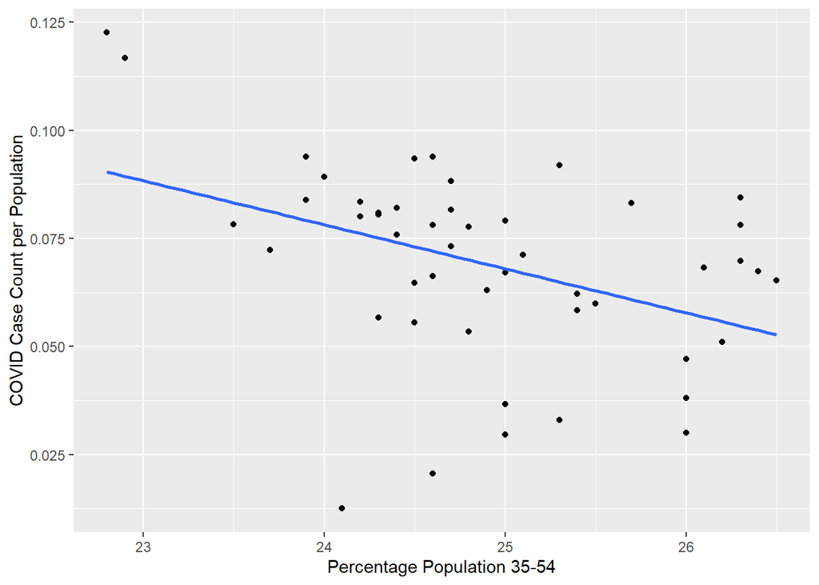

```r
 ggplot(master_copy_2020, aes(x = Percentage_population_35_54, y = covid_case_count_per_pop)) +
  geom_point() +
  geom_smooth(method = "lm", se = FALSE) +
  labs(x = "Percentage Population 35-54", y = "COVID Case Count per Population")
```

```r
 "Percentage Population 55-64 vs COVID Case Count per Population"
```

```
## [1] "Percentage Population 55-64 vs COVID Case Count per Population"
```

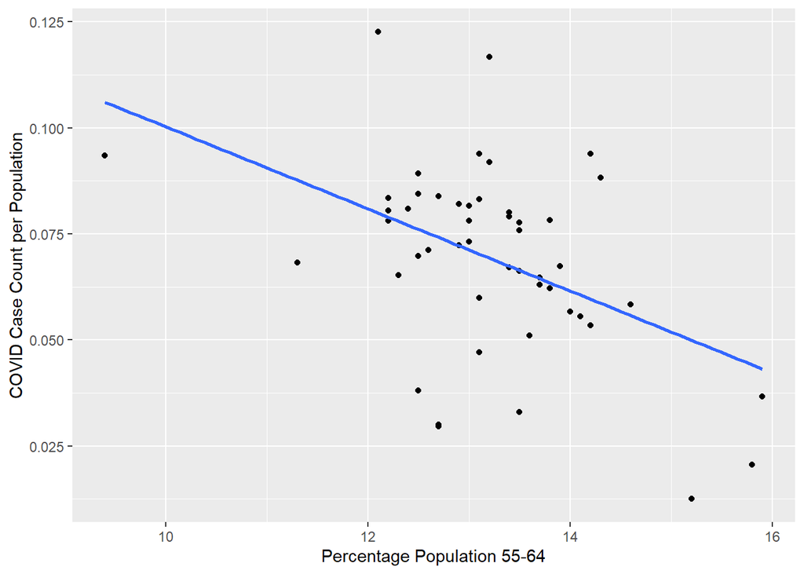

```r
 ggplot(master_copy_2020, aes(x = Percentage_population_55_64, y = covid_case_count_per_pop)) +
  geom_point() +
  geom_smooth(method = "lm", se = FALSE) +
  labs(x = "Percentage Population 55-64", y = "COVID Case Count per Population")
```

```r
 "Percentage Population 65 and Older vs COVID Case Count per Population"
```

```
## [1] "Percentage Population 65 and Older vs COVID Case Count per Population"
```

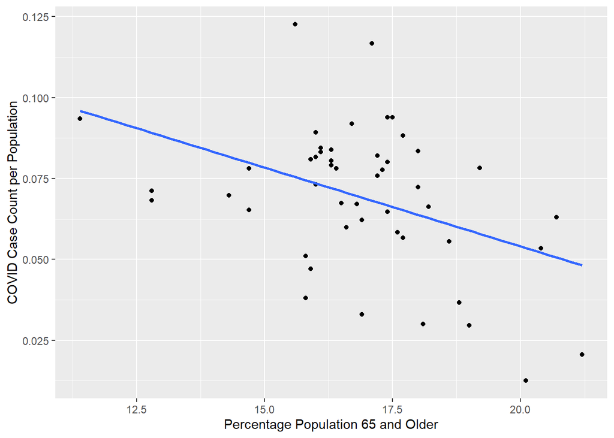

```r
 ggplot(master_copy_2020, aes(x = Percentage_population_65_and_older, y = covid_case_count_per_pop)) +
  geom_point() +
  geom_smooth(method = "lm", se = FALSE) +
  labs(x = "Percentage Population 65 and Older", y = "COVID Case Count per Population")
```

```r
 "Average White Percentage (including Hispanic) vs COVID Case Count per Population"
```

```
## [1] "Average White Percentage (including Hispanic) vs COVID Case Count per Population"
```

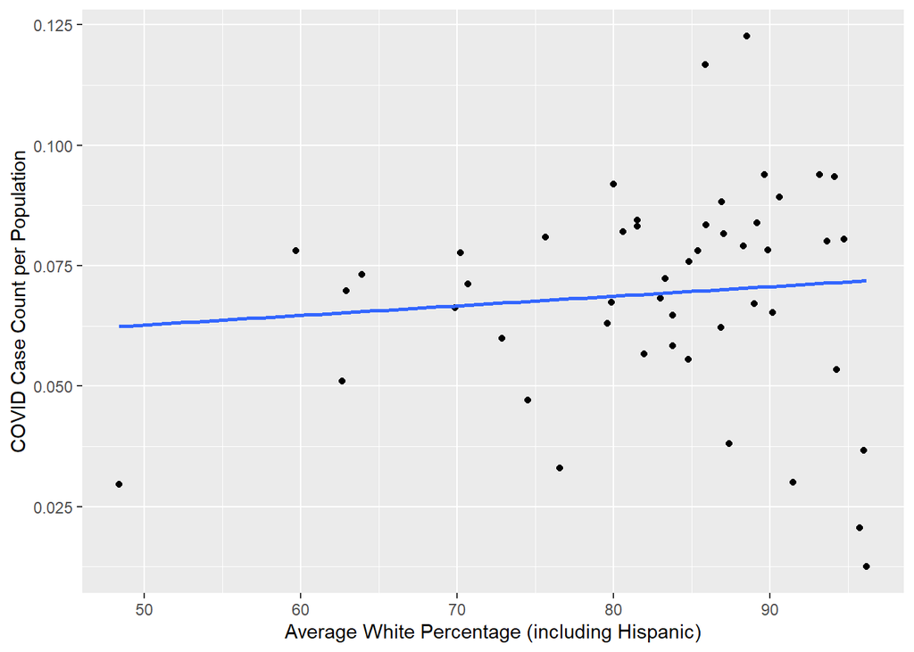

```r
ggplot(master_copy_2020, aes(x = White_including_Hispanic_percent, y = covid_case_count_per_pop)) +
  geom_point() +
  geom_smooth(method = "lm", se = FALSE) +
  labs(x = "Average White Percentage (including Hispanic)", y = "COVID Case Count per Population")
```

```r
"Average Black Percentage (including Hispanic) vs COVID Case Count per Population"
```

```
## [1] "Average Black Percentage (including Hispanic) vs COVID Case Count per Population"
```

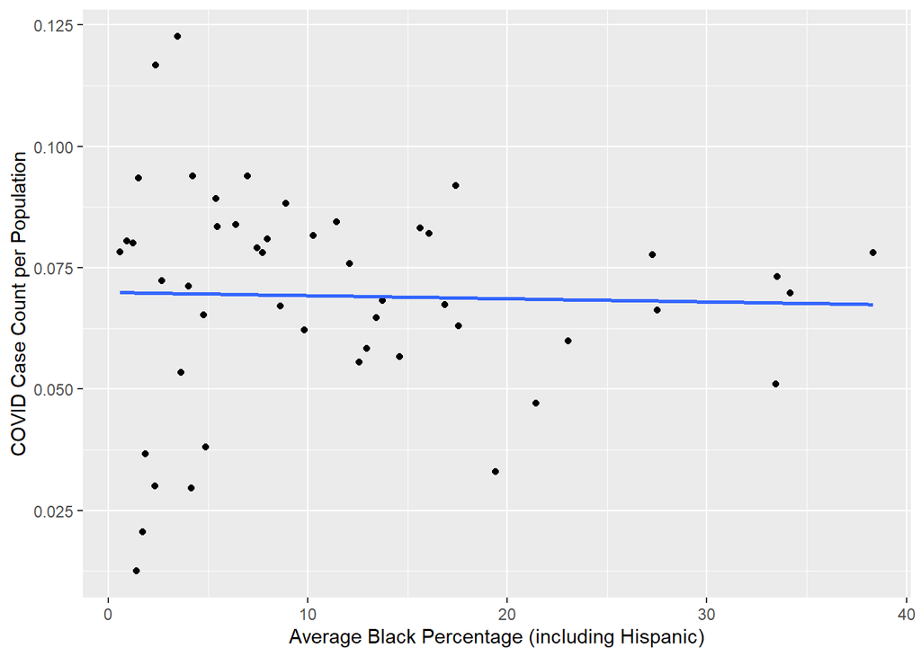

```r
ggplot(master_copy_2020, aes(x = Black_including_Hispanic_Percent, y = covid_case_count_per_pop)) +
  geom_point() +
  geom_smooth(method = "lm", se = FALSE) +
  labs(x = "Average Black Percentage (including Hispanic)", y = "COVID Case Count per Population")
```

```r
 "Average Other Percentage (including Hispanic) vs COVID Case Count per Population"
```

```
## [1] "Average Other Percentage (including Hispanic) vs COVID Case Count per Population"
```

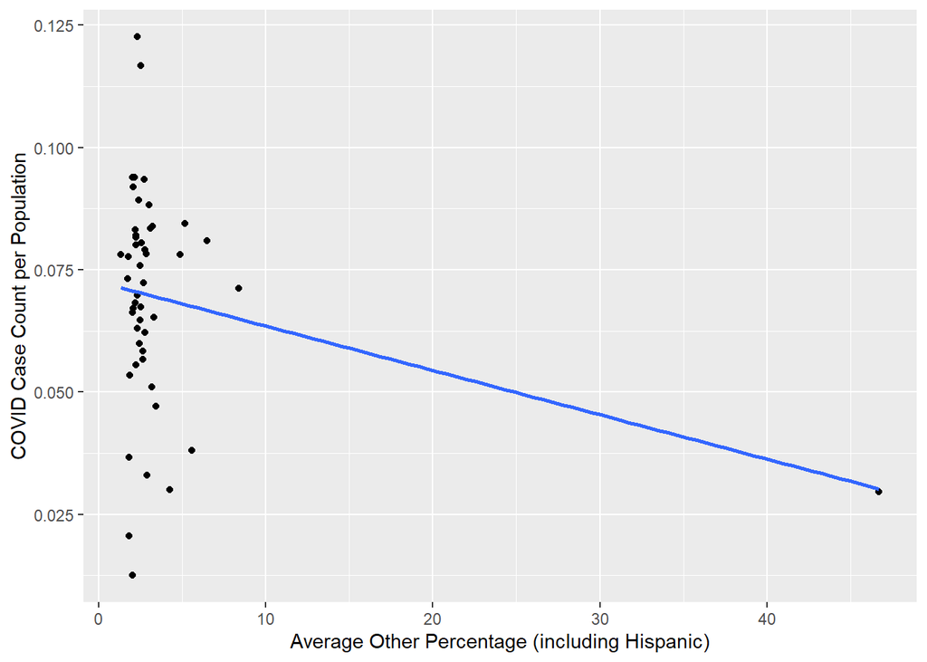

```r
ggplot(master_copy_2020, aes(x = Other_including_Hispanic_Percent, y = covid_case_count_per_pop)) +
  geom_point() +
  geom_smooth(method = "lm", se = FALSE) +
  labs(x = "Average Other Percentage (including Hispanic)", y = "COVID Case Count per Population")
```

```r
"Average American Indian Percentage (including Hispanic) vs COVID Case Count per Population"
```

```
## [1] "Average American Indian Percentage (including Hispanic) vs COVID Case Count per Population"
```

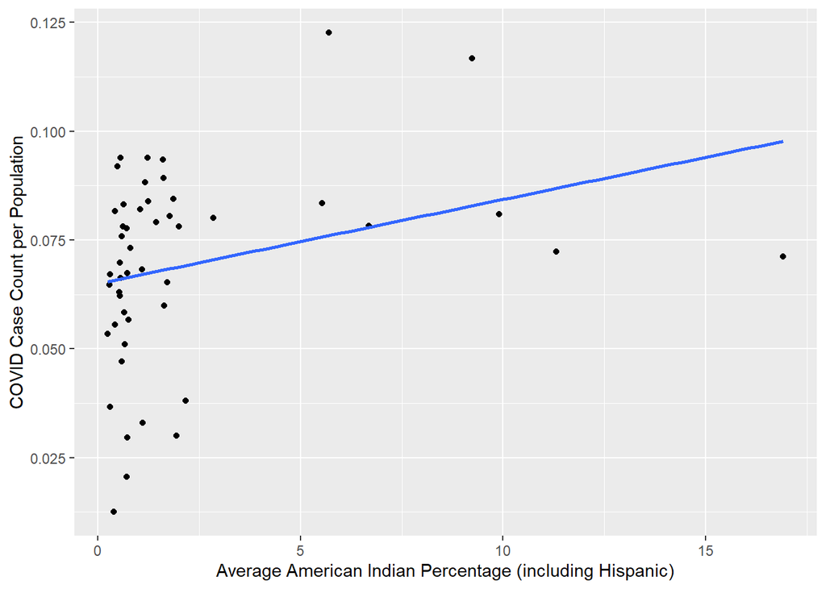

```r
 ggplot(master_copy_2020, aes(x = American_Indian_including_Hispanic_Percent, y = covid_case_count_per_pop)) +
  geom_point() +
  geom_smooth(method = "lm", se = FALSE) +
  labs(x = "Average American Indian Percentage (including Hispanic)", y = "COVID Case Count per Population")
```

##### Model 3

- **Analyze the model’s performance and summarize your findings.**

  **`Here is the model summary:`**
  1. **Coefficients**:
     - **Intercept**: The intercept (Intercept) is 8.398e-02, which represents the estimated COVID-19 case count per population when all predictor variables are zero.
     - **Total_Hospitals**: The coefficient estimate for Total_Hospitals is 3.099e-05. However, it is not statistically significant (p = 0.3980), suggesting that the total number of hospitals available may not have a significant impact on the COVID-19 case count per population.
     - **Total_Order**: The coefficient estimate for Total_Order is -1.715e-07. It is also not statistically significant (p = 0.6456), indicating that the average number of mask orders issued may not have a significant impact on the COVID-19 case count per population.
     - **Avg_Households_2020**: The coefficient estimate for Avg_Households_2020 is -6.267e-05, and it is statistically significant (p = 0.0225, indicated by ‘*’). This suggests that the average number of households in 2020 has a significant negative association with the COVID-19 case count per population. Specifically, for every one-unit increase in the average number of households, the COVID-19 case count per population decreases by approximately 6.267e-05 units, holding other variables constant.
  2. **Residuals**:
     - The residuals represent the differences between the observed and predicted values of the response variable.
     - The minimum residual is -0.056415, and the maximum residual is 0.043878.
  3. **Model Fit**:
     - The residual standard error is 0.02175, indicating the average deviation of the observed values from the fitted values.
     - The multiple R-squared value is 0.1139, suggesting that approximately 11.39% of the variability in the response variable is explained by the predictor variables in the model.
     - The adjusted R-squared value is 0.05485, which adjusts the R-squared value for the number of predictors in the model.
     - The F-statistic tests the overall significance of the model. With a p-value of 0.1385, we fail to reject the null hypothesis that all coefficients are zero, indicating that the model as a whole may not be statistically significant in explaining the variability in the response variable.

  Overall, this model suggests that the average number of households in 2020 has a significant negative association with the COVID-19 case count per population, while the total number of hospitals available and the average number of mask orders issued may not have significant effects. However, the overall explanatory power of the model is relatively low.

```r
# Linear Regression with Hospitals available, mask orders average household in year 2020
lm_model3 <- train(covid_case_count_per_pop ~ Total_Hospitals +
                        Total_Order + Avg_Households_2020,
                     data = master_copy_2020, method = "lm")

summary(lm_model3)
```

```
##
## Call:
## lm(formula = .outcome ~ ., data = dat)
##
## Residuals:
##       Min        1Q    Median        3Q       Max
## -0.056415 -0.010378  0.003733  0.011671  0.043878
##
## Coefficients:
##                       Estimate Std. Error t value Pr(>|t|)
## (Intercept)          8.398e-02  8.788e-03   9.555 2.12e-12 ***
## Total_Hospitals      3.099e-05  3.632e-05   0.853   0.3980
## Total_Order         -1.715e-07  3.705e-07  -0.463   0.6456
## Avg_Households_2020 -6.267e-05  2.652e-05  -2.363   0.0225 *
## ---
## Signif. codes:  0 '***' 0.001 '**' 0.01 '*' 0.05 '.' 0.1 ' ' 1
##
## Residual standard error: 0.02175 on 45 degrees of freedom
## Multiple R-squared:  0.1139, Adjusted R-squared:  0.05485
## F-statistic: 1.929 on 3 and 45 DF,  p-value: 0.1385
```

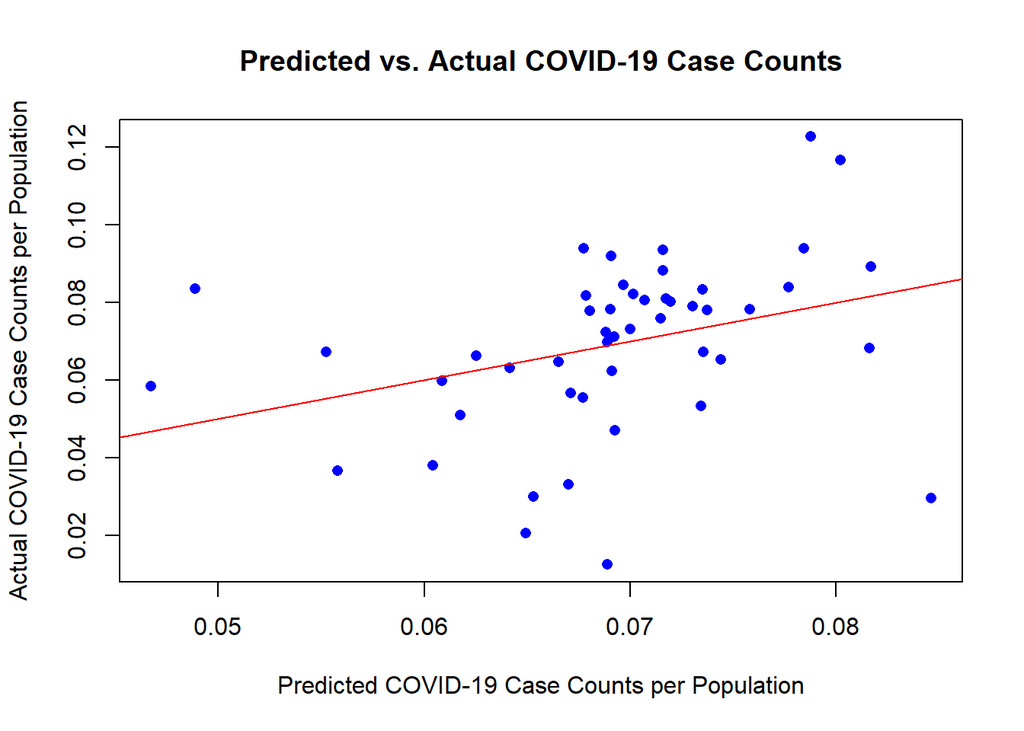

```r
# Predict COVID-19 case counts using the linear regression model
predictions <- predict(lm_model3)

# Create a scatter plot of actual vs. predicted COVID-19 case counts
plot(y= master_copy_2020$covid_case_count_per_pop, x= predictions,
     main = "Predicted vs. Actual COVID-19 Case Counts",
     ylab = "Actual COVID-19 Case Counts per Population",
     xlab = "Predicted COVID-19 Case Counts per Population",
     col = "blue",
     pch = 16)

# Add a diagonal line to represent perfect predictions
abline(0, 1, col = "red")
```

```r
# Create scatter plots with fitted regression lines for each predictor

    "Total Hospitals vs COVID Case Count per Population"
```

```
## [1] "Total Hospitals vs COVID Case Count per Population"
```

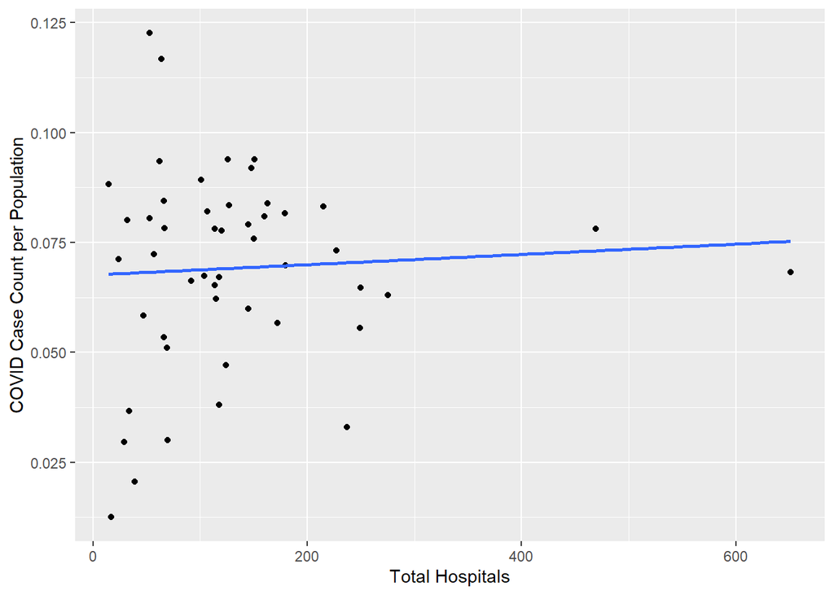

```r
ggplot(master_copy_2020, aes(x = Total_Hospitals, y = covid_case_count_per_pop)) +
  geom_point() +
  geom_smooth(method = "lm", se = FALSE) +
  labs(x = "Total Hospitals", y = "COVID Case Count per Population")
```

```r
    "Total Mask Orders vs COVID Case Count per Population"
```

```
## [1] "Total Mask Orders vs COVID Case Count per Population"
```

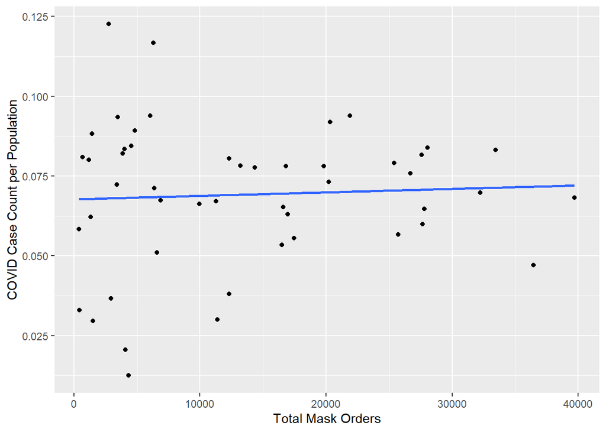

```r
ggplot(master_copy_2020, aes(x = Total_Order, y = covid_case_count_per_pop)) +
  geom_point() +
  geom_smooth(method = "lm", se = FALSE) +
  labs(x = "Total Mask Orders", y = "COVID Case Count per Population")
```

```r
    "Average Households in 2020 vs COVID Case Count per Population"
```

```
## [1] "Average Households in 2020 vs COVID Case Count per Population"
```

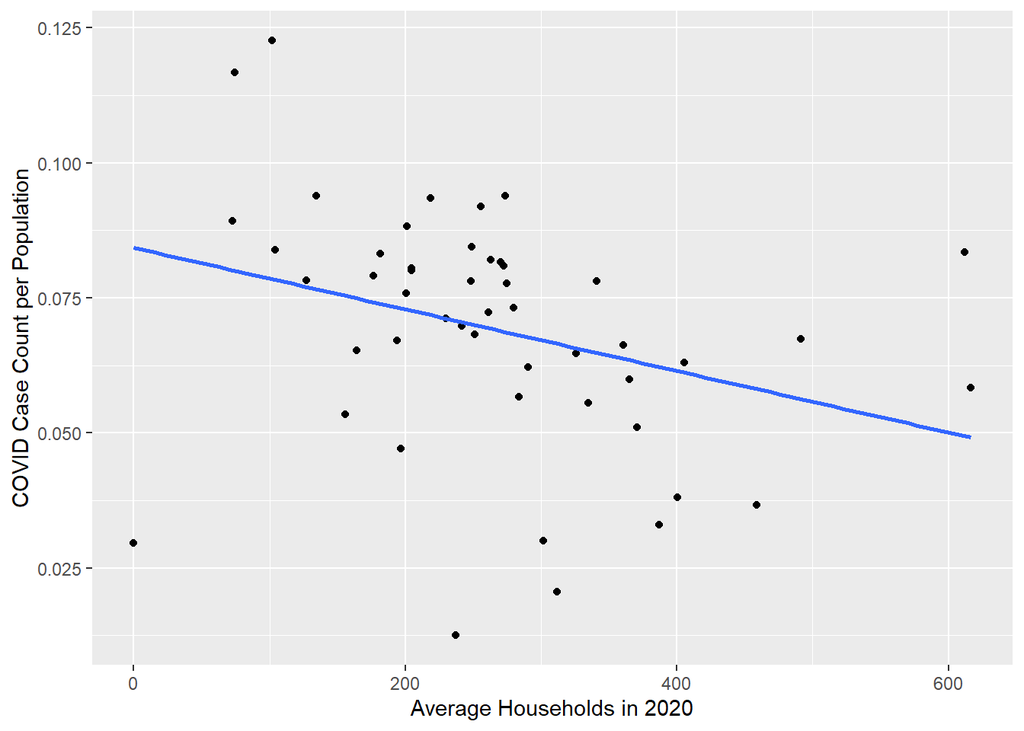

```r
 ggplot(master_copy_2020, aes(x = Avg_Households_2020, y = covid_case_count_per_pop)) +
  geom_point() +
  geom_smooth(method = "lm", se = FALSE) +
  labs(x = "Average Households in 2020", y = "COVID Case Count per Population")
```

### Ridge Regression

##### Model 1

```r
# Define response variable and predictor variables
response_var <- "covid_case_count_per_pop"
predictor_vars <- c("Poverty_Percentage_2020",
                    "avg_annual_death_from_COPD_2020",
                    "Median_Household_Income_2020",
                    "avg_total_population_2020",
                    "Percentage_stayed_at_home")

# Subset data to include only response and predictor variables
data_subset <- master_copy_2020[c(response_var, predictor_vars)]

# Convert response and predictor variables to matrix format
x <- as.matrix(data_subset[, predictor_vars])
y <- as.matrix(data_subset[, response_var])

# Perform ridge regression
ridge_model <- glmnet(x, y, alpha = 0)  # alpha = 0 for ridge regression

# Get summary information
ridge_model
```

```
##
## Call:  glmnet(x = x, y = y, alpha = 0)
##
##     Df %Dev Lambda
## 1    5 0.00 6.2390
## 2    5 0.09 5.6840
## 3    5 0.10 5.1790
## 4    5 0.11 4.7190
## 5    5 0.12 4.3000
## 6    5 0.13 3.9180
## 7    5 0.14 3.5700
## 8    5 0.16 3.2530
## 9    5 0.17 2.9640
## 10   5 0.19 2.7010
## 11   5 0.21 2.4610
```

[output cut: 89 more lines]

```r
coef(ridge_model, s = 0.2)  # Replace lambda value with any value you are interested in
```

```
## 6 x 1 sparse Matrix of class "dgCMatrix"
##                                            s1
## (Intercept)                      7.217437e-02
## Poverty_Percentage_2020          5.785748e-03
## avg_annual_death_from_COPD_2020 -8.341017e-07
## Median_Household_Income_2020    -5.470422e-08
## avg_total_population_2020       -2.749782e-11
## Percentage_stayed_at_home        7.476285e-04
```

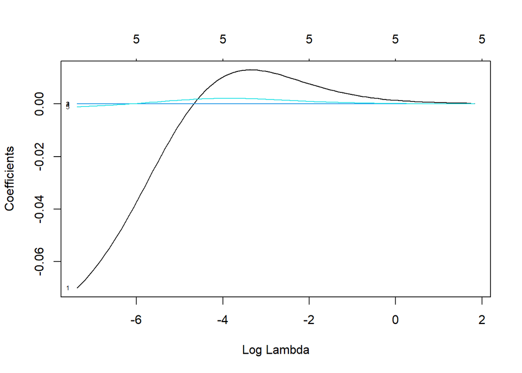

```r
# Plot coefficients
plot(ridge_model, xvar = "lambda", label = TRUE)
```

##### Model 2

```r
# Define response variable and predictor variables
response_var <- "covid_case_count_per_pop"
predictor_vars <- c("Total_Hospitals", "Total_Order", "Avg_Households_2020")

# Subset data to include only response and predictor variables
data_subset <- master_copy_2020[c(response_var, predictor_vars)]

# Convert response and predictor variables to matrix format
x <- as.matrix(data_subset[, predictor_vars])
y <- as.matrix(data_subset[, response_var])

# Perform ridge regression
ridge_model <- glmnet(x, y, alpha = 0)  # alpha = 0 for ridge regression

# Get summary information
print(ridge_model)
```

```
##
## Call:  glmnet(x = x, y = y, alpha = 0)
##
##     Df  %Dev Lambda
## 1    3  0.00 6.9820
## 2    3  0.07 6.3620
## 3    3  0.08 5.7970
## 4    3  0.09 5.2820
## 5    3  0.10 4.8120
## 6    3  0.11 4.3850
## 7    3  0.12 3.9950
## 8    3  0.13 3.6400
## 9    3  0.14 3.3170
## 10   3  0.15 3.0220
## 11   3  0.17 2.7540
```

[output cut: 89 more lines]

```r
coef(ridge_model, s = 0.1)  # Replace lambda value with any value you are interested in
```

```
## 4 x 1 sparse Matrix of class "dgCMatrix"
##                                s1
## (Intercept)          7.144037e-02
## Total_Hospitals      2.246147e-06
## Total_Order          1.454172e-08
## Avg_Households_2020 -1.036804e-05
```

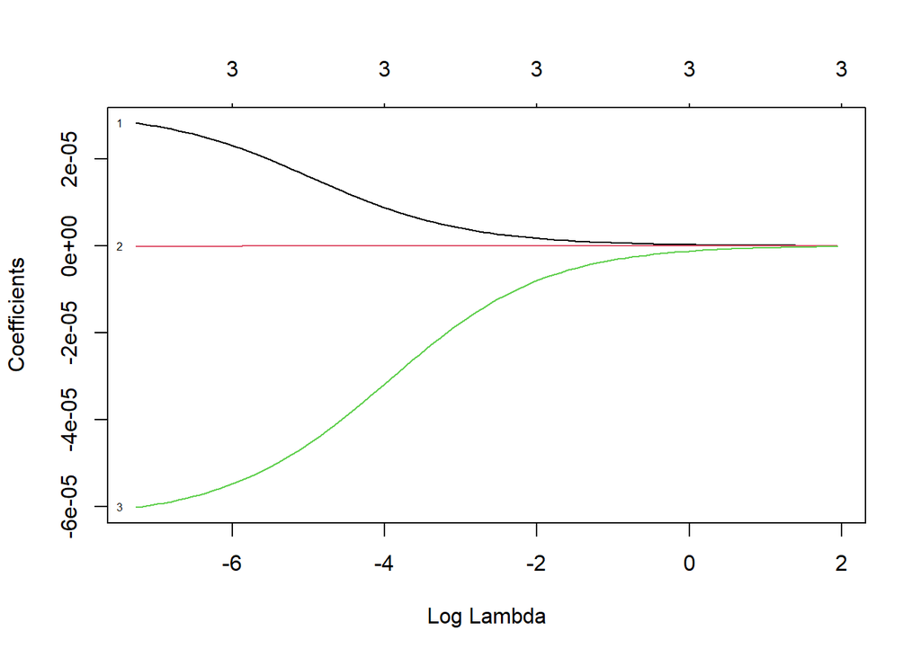

```r
# Plot coefficients
plot(ridge_model, xvar = "lambda", label = TRUE)
```

#### K-Nearest Neighbors

##### Model 1

- **Analyze the model’s performance and summarize your findings.**

  **`Here is the model summary:`**
  1. **RMSE (Root Mean Squared Error)**: This metric measures the average deviation of the predicted values from the actual values. A lower RMSE indicates better model performance. In your case, the RMSE is approximately 0.022, suggesting that, on average, the predicted COVID-19 case count per population deviates from the actual count by around 0.022 units.
  2. **R-squared (Coefficient of Determination)**: This metric indicates the proportion of the variance in the target variable that is explained by the model. It ranges from 0 to 1, with higher values indicating a better fit. In your case, the R-squared value is approximately 0.016, which means that only about 1.6% of the variance in the COVID-19 case count per population is explained by the model.
  3. **MAE (Mean Absolute Error)**: This metric measures the average absolute difference between the predicted and actual values. Similar to RMSE, a lower MAE indicates better model performance. Your MAE is approximately 0.016, implying that, on average, the predicted COVID-19 case count per population deviates from the actual count by around 0.016 units.

  Overall, based on these metrics, the KNN model seems to have limited predictive performance, as indicated by the relatively high RMSE and MAE values and the low R-squared value. This suggests that the model may not be capturing the underlying patterns in the data effectively or that the chosen features may not be strong predictors of the COVID-19 case count per population.

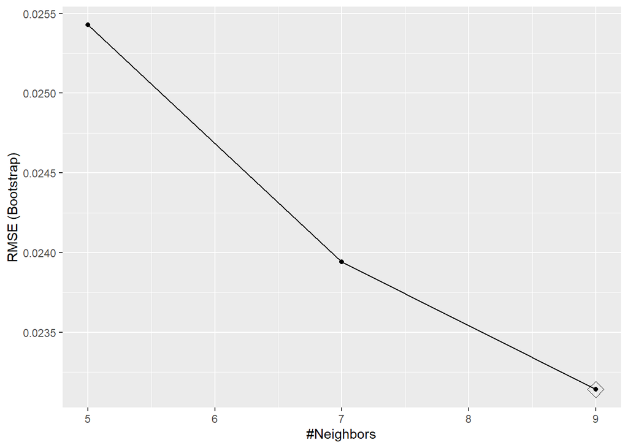

```r
# K-Nearest Neighbors (KNN)_1
knn_model1 <- train(covid_case_count_per_pop ~ Poverty_Percentage_2020 +
                   avg_annual_death_from_COPD_2020 +
                   Median_Household_Income_2020 +
                   avg_total_population_2020 +
                   Percentage_stayed_at_home,
                   data = master_copy_2020,
                   method = "knn")

ggplot(knn_model1, highlight = TRUE)
```

```r
yhat.knn.reg <- predict(knn_model1, newdata = master_copy_2020)
postResample(yhat.knn.reg,master_copy_2020$covid_case_count_per_pop)
```

```
##       RMSE   Rsquared        MAE
## 0.02219649 0.01582131 0.01601092
```

##### Model 2

- **Analyze the model’s performance and summarize your findings.**

  **`Here is the model summary:`**
  1. **RMSE (Root Mean Squared Error)**: The RMSE value of approximately 0.0213 indicates the average deviation between the predicted COVID-19 case count per population and the actual values. Lower RMSE values suggest better model performance, indicating that, on average, the model’s predictions are close to the actual values.
  2. **R-squared (Coefficient of Determination)**: The R-squared value of approximately 0.0958 represents the proportion of variance in the COVID-19 case count per population explained by the model. A higher R-squared value indicates that the model explains more variance in the target variable. In this case, the R-squared value is relatively low, suggesting that the model may not be capturing a significant portion of the variance in the data.
  3. **MAE (Mean Absolute Error)**: The MAE value of approximately 0.0167 represents the average absolute difference between the predicted COVID-19 case count per population and the actual values. Similar to RMSE, lower MAE values indicate better model performance, suggesting that, on average, the model’s predictions are closer to the actual values.

  Overall, while the RMSE and MAE values are relatively low, indicating good predictive accuracy on average, the R-squared value is quite low, suggesting that the model may not explain a large portion of the variance in the COVID-19 case count per population. This indicates that the model might not capture all the relevant factors influencing COVID-19 case counts effectively. Further investigation or refinement of the model may be necessary to improve its performance.

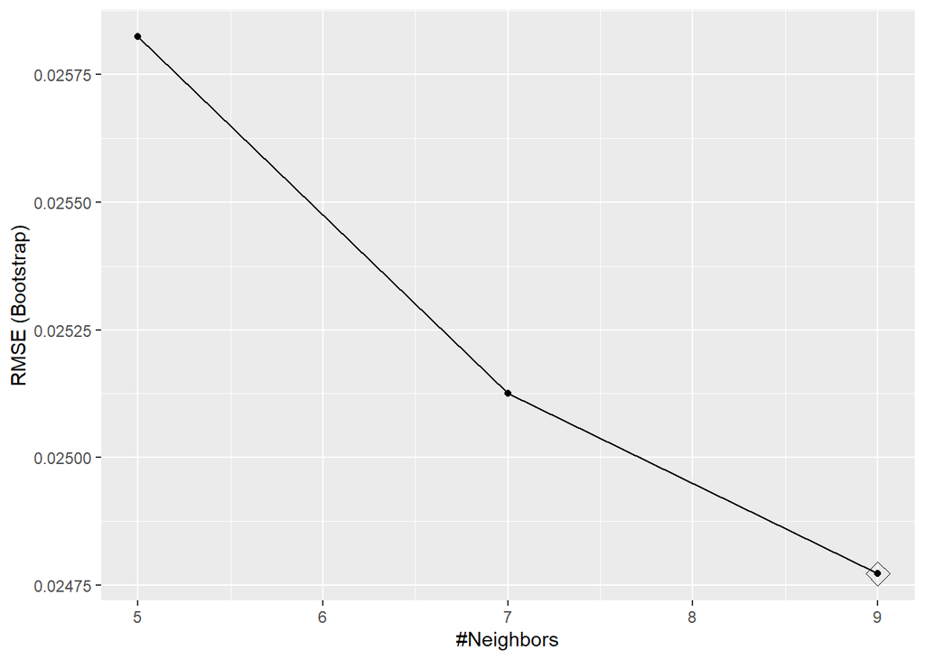

```r
# K-Nearest Neighbors (KNN)_2
knn_model2 <- train(covid_case_count_per_pop ~ Total_Hospitals +
                        Total_Order + Avg_Households_2020,
                       data = master_copy_2020,
                       method = "knn")

ggplot(knn_model2, highlight = TRUE)
```

```r
yhat.knn.reg <- predict(knn_model2, newdata = master_copy_2020)
postResample(yhat.knn.reg,master_copy_2020$covid_case_count_per_pop)
```

```
##       RMSE   Rsquared        MAE
## 0.02125324 0.09577786 0.01668759
```

### Model Assessment/Evaluation -Linear regression

```r
#Predictive Mode1- Linear regression

# Set seed for reproducibility
set.seed(123)

# Define cross-validation settings
ctrl <- trainControl(method = "cv", number = 5)

# Train linear regression model with cross-validation
lm_model1_cv <- train(covid_case_count_per_pop ~ Poverty_Percentage_2020 +
                      avg_annual_death_from_COPD_2020 +
                      Median_Household_Income_2020 +
                      avg_total_population_2020 +
                      Percentage_stayed_at_home,
                      data = master_copy_2020,
                      method = "lm",
                      trControl = ctrl)

# Summary of the cross-validated linear regression model
summary(lm_model1_cv)
```

```
##
## Call:
## lm(formula = .outcome ~ ., data = dat)
##
## Residuals:
##       Min        1Q    Median        3Q       Max
## -0.062010 -0.011425  0.003075  0.013709  0.045131
##
## Coefficients:
##                                   Estimate Std. Error t value Pr(>|t|)
## (Intercept)                      1.434e-01  5.081e-02   2.822   0.0072 **
## Poverty_Percentage_2020         -8.873e-02  1.312e-01  -0.676   0.5024
## avg_annual_death_from_COPD_2020 -1.146e-05  2.001e-05  -0.573   0.5699
## Median_Household_Income_2020    -8.500e-07  5.080e-07  -1.673   0.1016
## avg_total_population_2020       -3.528e-11  5.872e-10  -0.060   0.9524
## Percentage_stayed_at_home       -1.732e-03  1.340e-02  -0.129   0.8978
## ---
## Signif. codes:  0 '***' 0.001 '**' 0.01 '*' 0.05 '.' 0.1 ' ' 1
##
## Residual standard error: 0.02242 on 43 degrees of freedom
## Multiple R-squared:  0.1004, Adjusted R-squared:  -0.004189
## F-statistic:  0.96 on 5 and 43 DF,  p-value: 0.4529
```

```r
# Print model details
print(lm_model1_cv)
```

```
## Linear Regression
##
## 49 samples
##  5 predictor
##
## No pre-processing
## Resampling: Cross-Validated (5 fold)
## Summary of sample sizes: 41, 40, 38, 38, 39
## Resampling results:
##
##   RMSE        Rsquared    MAE
##   0.02265605  0.07068904  0.01737947
##
## Tuning parameter 'intercept' was held constant at a value of TRUE
```

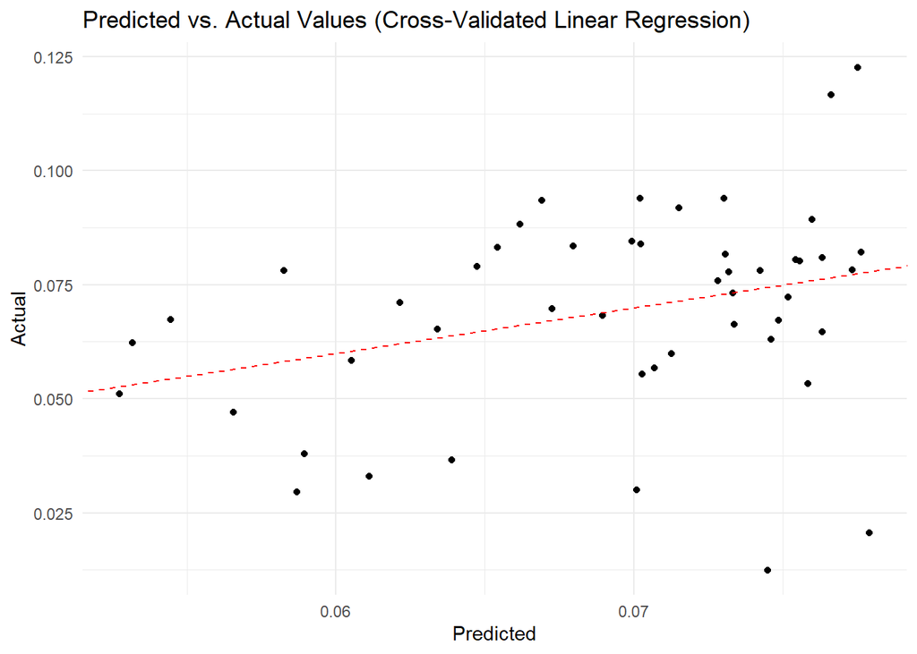

```r
# Extract actual vs. predicted values
predicted_vs_actual <- data.frame(Actual = master_copy_2020$covid_case_count_per_pop,
                                   Predicted = predict(lm_model1_cv))

# Plot actual vs. predicted values
ggplot(predicted_vs_actual, aes(y = Actual, x = Predicted)) +
  geom_point() +
  geom_abline(intercept = 0, slope = 1, color = "red", linetype = "dashed") +
  labs(y = "Actual", x = "Predicted",
       title = "Predicted vs. Actual Values (Cross-Validated Linear Regression)") +
  theme_minimal()
```

```r
# Evaluate model performance (mean of RMSE across folds)
print(paste("Mean RMSE:", mean(lm_model1_cv$results$RMSE)))
```

```
## [1] "Mean RMSE: 0.0226560489272102"
```

```r
#Predictive Model3- Linear regression
# Define the control parameters for cross-validation
ctrl <- trainControl(method = "cv",    # Cross-validation method
                     number = 10,      # Number of folds
                     verboseIter = TRUE,  # Print progress
                     returnResamp = "all",  # Return resampling results
                     savePredictions = TRUE)  # Save predictions for each fold


# Train the linear regression model with cross-validation
lm_model3_cv <- train(covid_case_count_per_pop ~ Total_Hospitals +
                      Total_Order + Avg_Households_2020,
                      data = master_copy_2020,
                     method = "lm",
                     trControl = ctrl)
```

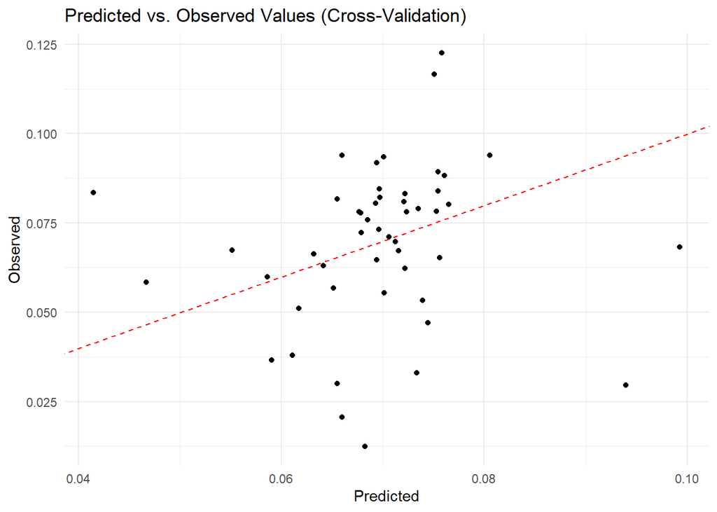

```r
# Extract cross-validated predictions
predictions <- lm_model3_cv$pred

#Create a scatter plot of observed vs. predicted values for each fold

ggplot(predictions, aes(y = obs, x = pred)) +
  geom_point() +
  geom_abline(slope = 1, intercept = 0, color = "red", linetype = "dashed") +
  labs(title = "Predicted vs. Observed Values (Cross-Validation)",
       y = "Observed", x = "Predicted") + theme_minimal()
```

### Model Assessment/Evaluation - Ridge Regression

```r
# Define response variable and predictor variables
response_var <- "covid_case_count_per_pop"
predictor_vars <- c("Poverty_Percentage_2020",
                    "avg_annual_death_from_COPD_2020",
                    "Median_Household_Income_2020",
                    "avg_total_population_2020",
                    "Percentage_stayed_at_home")

# Subset data to include only response and predictor variables
data_subset <- master_copy_2020[c(response_var, predictor_vars)]

# Convert response and predictor variables to matrix format
x <- as.matrix(data_subset[, predictor_vars])
y <- as.matrix(data_subset[, response_var])

# Perform cross-validated ridge regression
cv_fit <- cv.glmnet(x, y, alpha = 0)  # alpha = 0 for ridge regression
cv_fit
```

```
##
## Call:  cv.glmnet(x = x, y = y, alpha = 0)
##
## Measure: Mean-Squared Error
##
##     Lambda Index   Measure        SE Nonzero
## min  3.570     7 0.0005169 0.0001330       5
## 1se  6.239     1 0.0005170 0.0001329       5
```

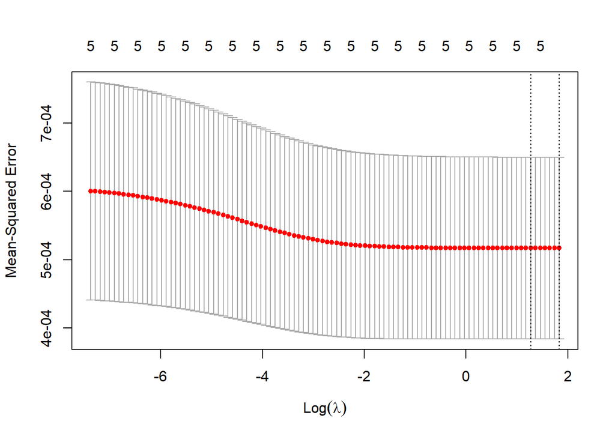

```r
# Plot cross-validation results
plot(cv_fit)
```

```r
# Select lambda with lowest mean cross-validated error
best_lambda <- cv_fit$lambda.min

# Train final ridge regression model with selected lambda
ridge_model_final <- glmnet(x, y, alpha = 0, lambda = best_lambda)

# Get summary information
ridge_model_final
```

```
##
## Call:  glmnet(x = x, y = y, alpha = 0, lambda = best_lambda)
##
##   Df %Dev Lambda
## 1  5 0.14   3.57
```

### Model Assessment/Evaluation - K-Nearest Neighbors

```r
# Define cross-validation settings
ctrl <- trainControl(method = "cv", number = 5)

# Train KNN model 1 with cross-validation
knn_model1_cv <- train(covid_case_count_per_pop ~ Poverty_Percentage_2020 +
                         avg_annual_death_from_COPD_2020 +
                         Median_Household_Income_2020 +
                         avg_total_population_2020 +
                         Percentage_stayed_at_home,
                         data = master_copy_2020,
                         method = "knn",
                         tuneGrid = data.frame(k=seq(1,15,1)),
                         trControl = ctrl)

# View of KNN model 1
knn_model1_cv
```

```
## k-Nearest Neighbors
##
## 49 samples
##  5 predictor
##
## No pre-processing
## Resampling: Cross-Validated (5 fold)
## Summary of sample sizes: 39, 40, 40, 39, 38
## Resampling results across tuning parameters:
##
##   k   RMSE        Rsquared    MAE
##    1  0.03079744  0.08161887  0.02400215
##    2  0.02611151  0.06373153  0.01843549
##    3  0.02394740  0.05573286  0.01802225
##    4  0.02301210  0.03510351  0.01716332
##    5  0.02314851  0.04391369  0.01756699
##    6  0.02353194  0.03100511  0.01758667
##    7  0.02319836  0.04491894  0.01727042
##    8  0.02294238  0.05853798  0.01724288
##    9  0.02268006  0.06634635  0.01680502
##   10  0.02203050  0.13112202  0.01671062
##   11  0.02215157  0.13950824  0.01688440
##   12  0.02215326  0.15488803  0.01668692
##   13  0.02242645  0.07203846  0.01707336
##   14  0.02250707  0.08947717  0.01714532
##   15  0.02224502  0.08877828  0.01685364
##
## RMSE was used to select the optimal model using the smallest value.
## The final value used for the model was k = 10.
```

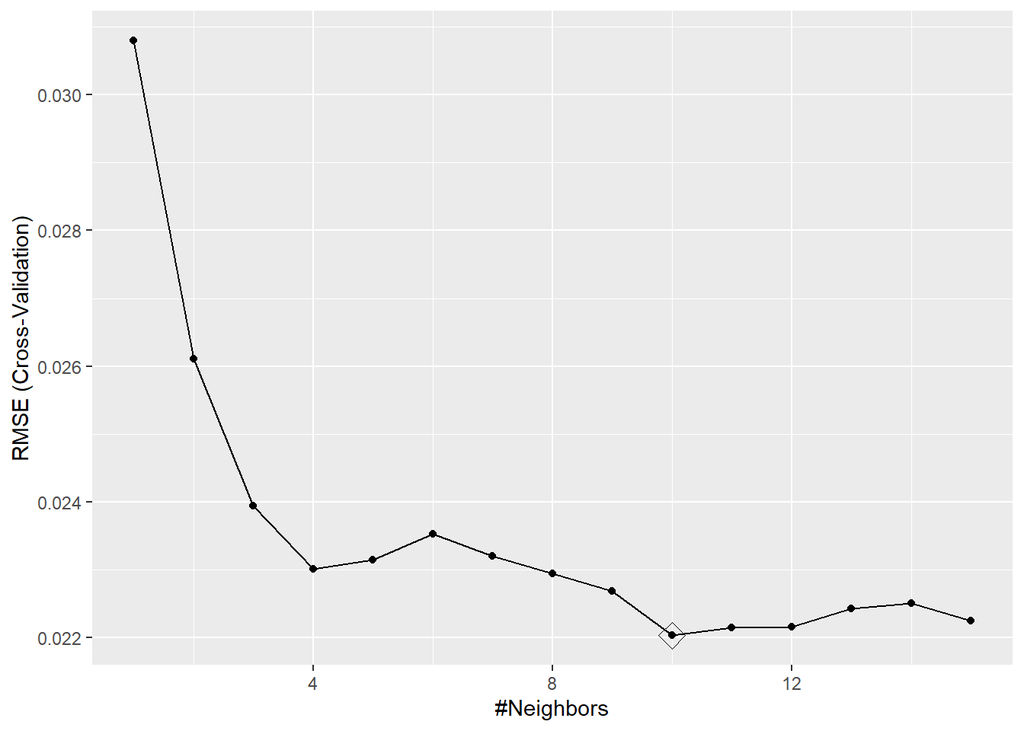

```r
ggplot(knn_model1_cv, highlight = TRUE)
```

```r
yhat.knn.reg <- predict(knn_model1_cv, newdata = master_copy_2020)
postResample(yhat.knn.reg,master_copy_2020$covid_case_count_per_pop)
```

```
##       RMSE   Rsquared        MAE
## 0.02195501 0.02525599 0.01607015
```

```r
# Train KNN model 2 with cross-validation
knn_model2_cv <- train(covid_case_count_per_pop ~ Total_Hospitals +
                         Total_Order + Avg_Households_2020,
                       data = master_copy_2020,
                       method = "knn",
                       tuneGrid = data.frame(k=seq(1,15,1)),
                       trControl = ctrl)

# View of KNN model 2
knn_model2_cv
```

```
## k-Nearest Neighbors
##
## 49 samples
##  3 predictor
##
## No pre-processing
## Resampling: Cross-Validated (5 fold)
## Summary of sample sizes: 38, 39, 40, 39, 40
## Resampling results across tuning parameters:
##
##   k   RMSE        Rsquared    MAE
##    1  0.03096992  0.07497013  0.02404944
##    2  0.02673967  0.04159568  0.02284053
##    3  0.02439329  0.08685981  0.01966797
##    4  0.02287388  0.04952155  0.01883660
##    5  0.02381864  0.05843012  0.01931770
##    6  0.02323373  0.03077489  0.01795959
##    7  0.02327323  0.04035987  0.01837530
##    8  0.02343107  0.03251149  0.01795365
##    9  0.02317536  0.04483913  0.01740810
##   10  0.02382813  0.09689212  0.01790621
##   11  0.02395814  0.07116160  0.01768426
##   12  0.02334363  0.01500193  0.01748597
##   13  0.02282589  0.01306465  0.01703257
##   14  0.02290781  0.01170681  0.01691643
##   15  0.02313123  0.05308629  0.01714810
##
## RMSE was used to select the optimal model using the smallest value.
## The final value used for the model was k = 13.
```

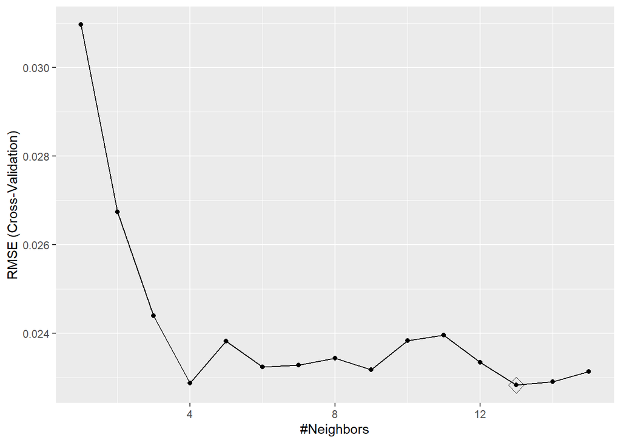

```r
ggplot(knn_model2_cv, highlight = TRUE)
```

```r
yhat.knn.reg <- predict(knn_model2_cv, newdata = master_copy_2020)
postResample(yhat.knn.reg,master_copy_2020$covid_case_count_per_pop)
```

```
##         RMSE     Rsquared          MAE
## 2.255181e-02 6.484879e-06 1.689961e-02
```